# Part II - PISA 2012 Data Exploration

## by Tioluwani Jaiye-Tikolo

## Investigation Overview

> For the presentation, I focus on the influence of the most looked at features against math, science, read, and total scores and introduce them in order. Aftewards the categorical features of interest are to be plotted against total scores one by one with violin, box, and scatter plots.

## Dataset Overview

> PISA is a survey of students' skills and knowledge as they approach the end of compulsory education. It is not a conventional school test. Rather than examining how well students have learned the school curriculum, it looks at how well prepared they are for life beyond school. Around 510,000 students in 65 economies took part in the PISA 2012 assessment of reading, mathematics and science representing about 28 million 15-year-olds globally. Of those economies, 44 took part in an assessment of creative problem solving and 18 in an assessment of financial literacy.

## Distribution of Gender

> There in a slight increase in percentages in the data as there are more females than males

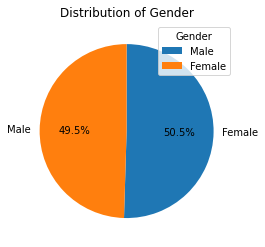

## Distribution of Math, Science and Reading Scores

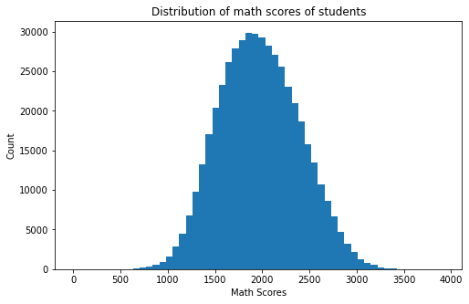

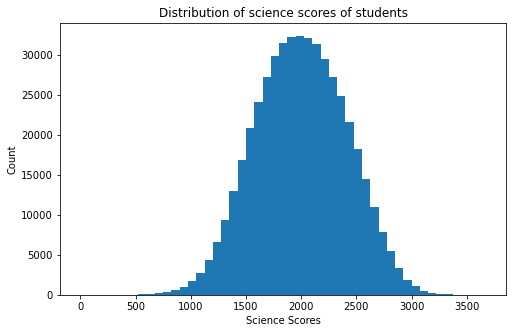

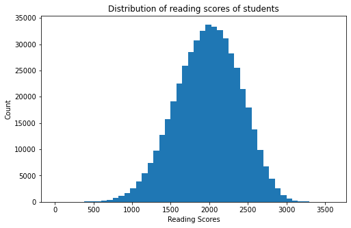

## Distribution of Total Scores

> Total scores is an aggregate of math, science and reading scores. Plotted across a large bin size, total scores displays the scores of students in three subjects.

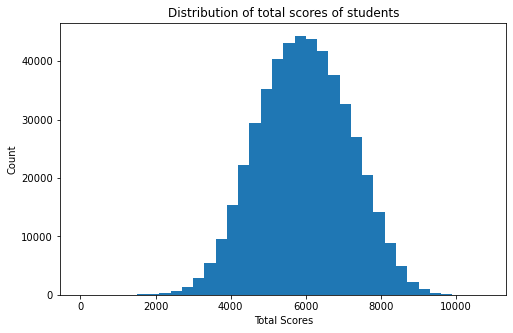

## Math Score vs. Science, Reading Scores

> These features are strongly related with one another posing the fact as one increases so does the other.

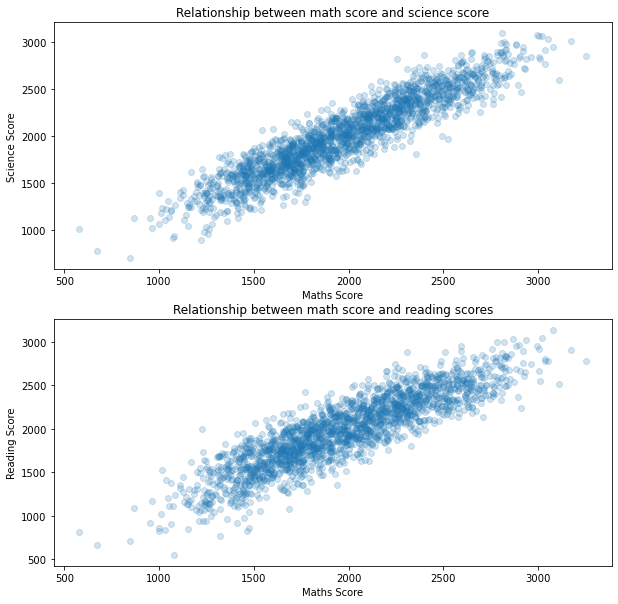

## Correlation Plot of Numeric Variables

> Math_Scores, Reading_Scores, Science_Scores, and Total_Scores are highly correlatated with one another and this is to be expected as Total_Scores ia a measure of the sum of math, reading and science scores. Wealth is also faintly correlated with the scores of the subject and the rest of the features bear low correlation with one another.

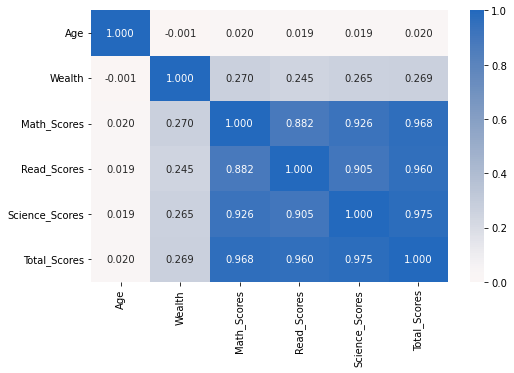

## Total Scores vs. Truancy of Students

> Students with no late trauncies and skips have higher total scores than others and also that students with one or two trucnies in class have higher total scores than those with higher skips.

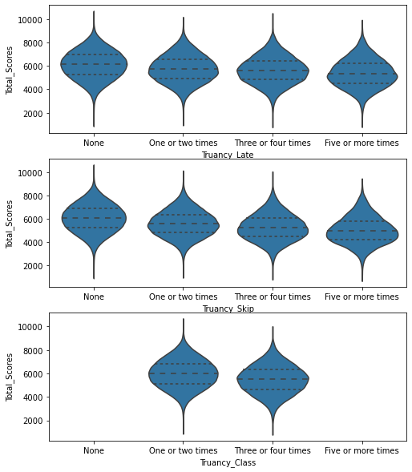

## Total Scores vs. Math Interest in Enjoy Reading, Lessons, Enjoy Lessons

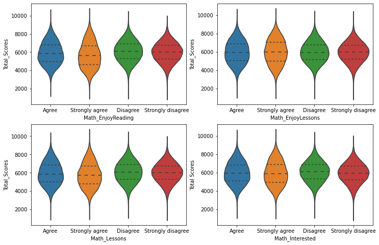

## Total Scores vs. Attitude Features of Students

> Most sutudent disagree on being useful for school work, more students strongly agree to being sources of information, they disagree in being not suitable for school work, having fun with home work, being troublesome and unrealiable.

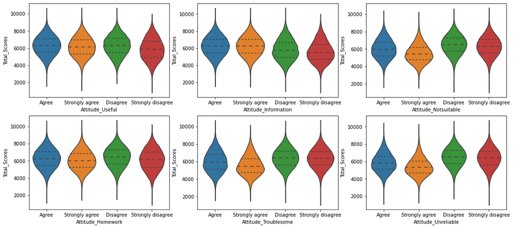

## Total Scores vs. Out Study Subjects

> Most students do not study maths, science, or others outside of school but study for less than two hours in each subject.

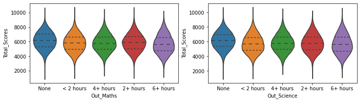

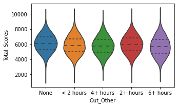

## Attitudes of Students against Interest

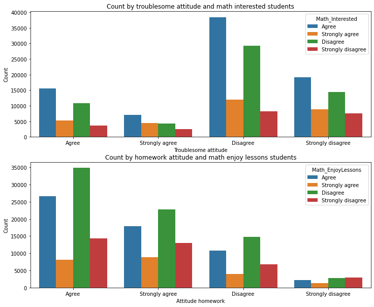

## Gender vs Out Study Maths and Science

> The highest count is placed on None for both of them also we can clearly seen an increase in female not attending either maths or science for out of study classes.

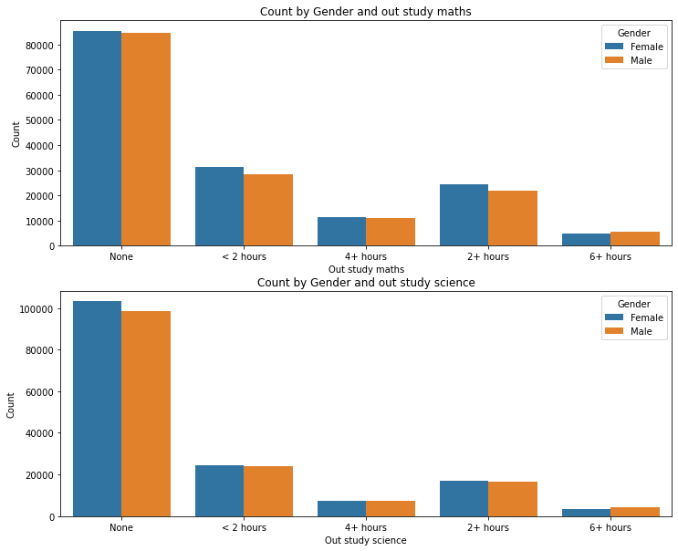

## Total Scores vs. Parents Job

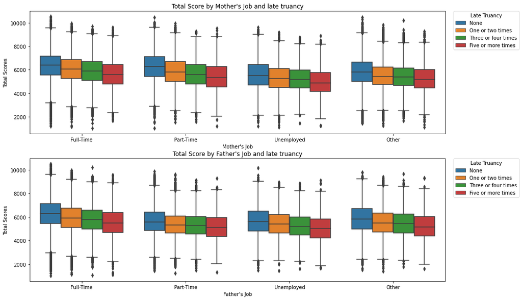

## Total Scores vs. Parents Schooling

> It can be seen in both instances of mother's and father's schooling that parents with a finishing of Level 3A have children with higher total scores than the rest.

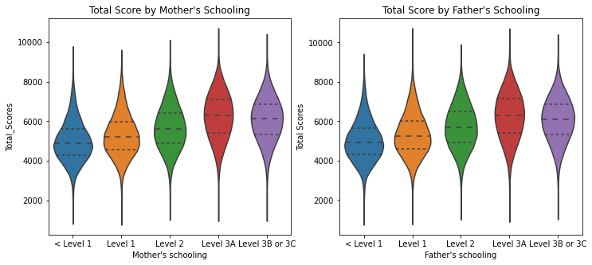

## Total Scores vs. Math, Read, Science scores and Math Lessons

> The relationship, between math, read and science scores and it is strongly correlated. So, the more students who agree to to math lessons having the scores in the subjects the more students will disagree and fufill the other categories as well.

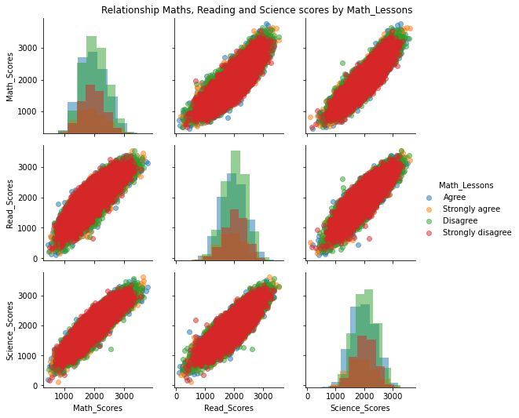

## Total Scores vs. Troublesome Attitude and Interest of Math

> The interested attitude is strong with students who disareee to having a torublesome attitude. This means that students with high total scores do not have the troublesome attitude.

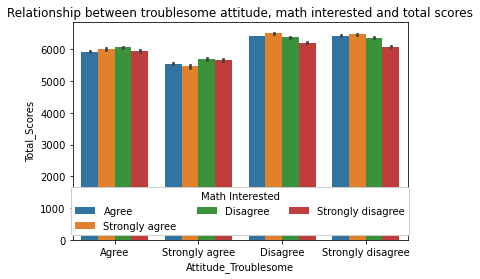

## Wealth by Out study Maths, and Science for Selected Total Scores

> The wealth of students greather and less than the mean of total scores by out study maths and out study science. The study time of out science for 6 + hours is greater than most hours in out maths. Most students higher than the mean score study science more than math for out study. For below the mean total score, 6+ hour study time seems proportionate in out maths and out science.

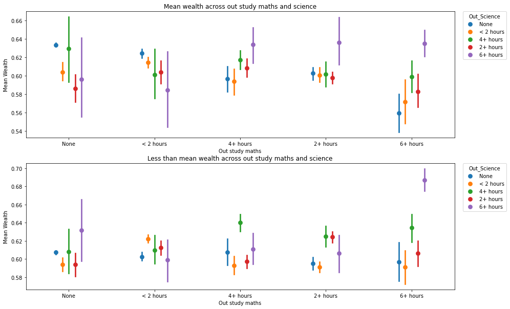